# Principal Component Analysis

Dataset sediments.sand.scaled

This dataset contains 18 individuals and 8 variables, 1 qualitative variable is considered as illustrative.

### 1. Study of the outliers

The analysis of the graphs does not detect any outlier.

### 2. Inertia distribution

The inertia of the first dimensions shows if there are strong relationships between variables and suggests the number of dimensions that should be studied.

The first two dimensions of PCA express **86.56%** of the total dataset inertia ; that means that 86.56% of the individuals (or variables) cloud total variability is explained by the plane. This percentage is high and thus the first plane represents an important part of the data variability. This value is strongly greater than the reference value that equals **61.06%**, the variability explained by this plane is thus highly significant (the reference value is the 0.95-quantile of the inertia percentages distribution obtained by simulating 583 data tables of equivalent size on the basis of a normal distribution).

From these observations, it is probably not useful to interpret the next dimensions.

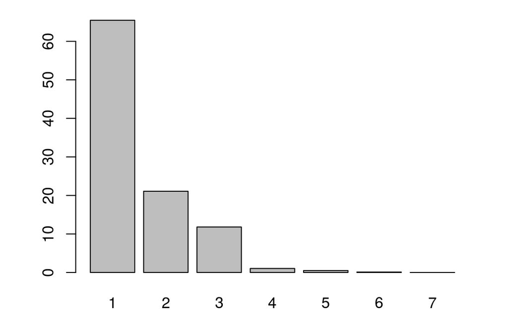

**Figure 2 - Decomposition of the total inertia on the components of the PCA** *The first factor is major: it expresses itself 65.46% of the data variability.* *Note that in such a case, the variability related to the other components might be meaningless, despite of a high percentage.*

An estimation of the right number of axis to interpret suggests to restrict the analysis to the description of the first 1 axis. These axis present an amount of inertia greater than those obtained by the 0.95-quantile of random distributions (65.46% against 38.61%). This observation suggests that only this axis is carrying a real information. As a consequence, the description will stand to these axis.

### 3. Description of the dimension 1

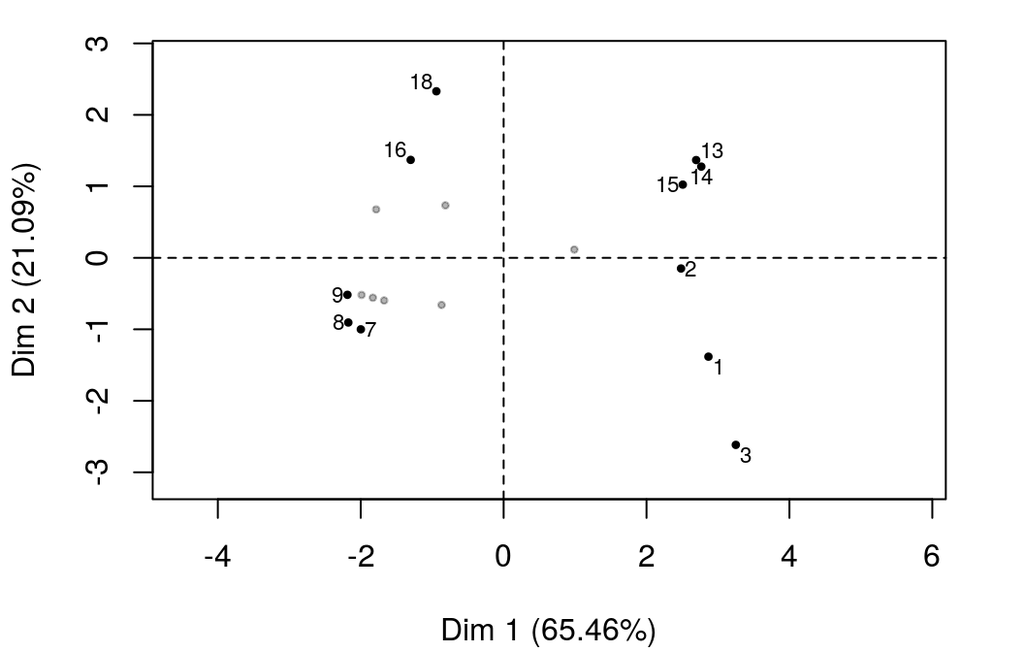

**Figure 3.1 - Individuals factor map (PCA)** *The labeled individuals are those with the higher contribution to the plane construction.*

The Wilks test p-value indicates which variable factors are the best separated on the plane (i.e. which one explain the best the distance between individuals).

```
##      station
## 1.590361e-09
```

There only is one possible qualitative variable to illustrate the distance between individuals : *station*.

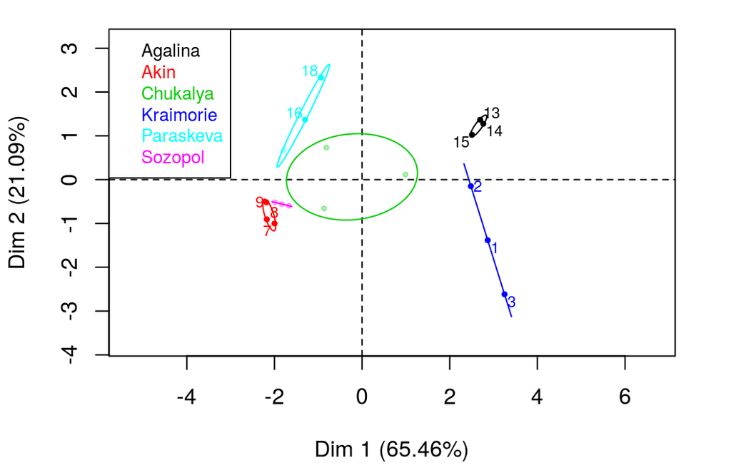

**Figure 3.2 - Individuals factor map (PCA)** *The labeled individuals are those with the higher contribution to the plane construction.* *The individuals are coloured after their category for the variable* station.

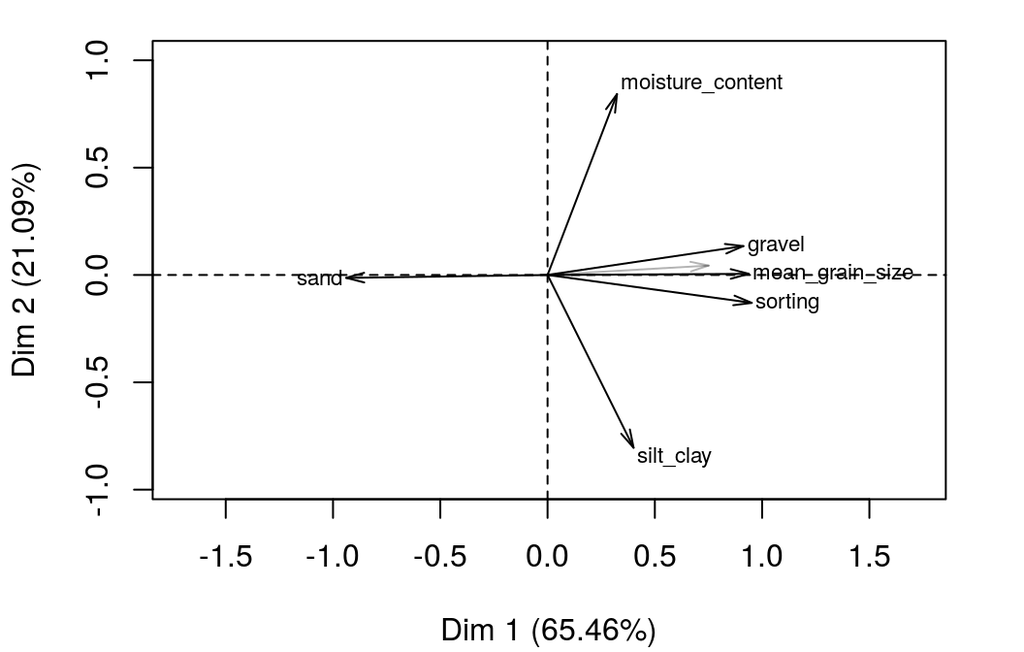

**Figure 3.3 - Variables factor map (PCA)** *The labeled variables are those the best shown on the plane.*

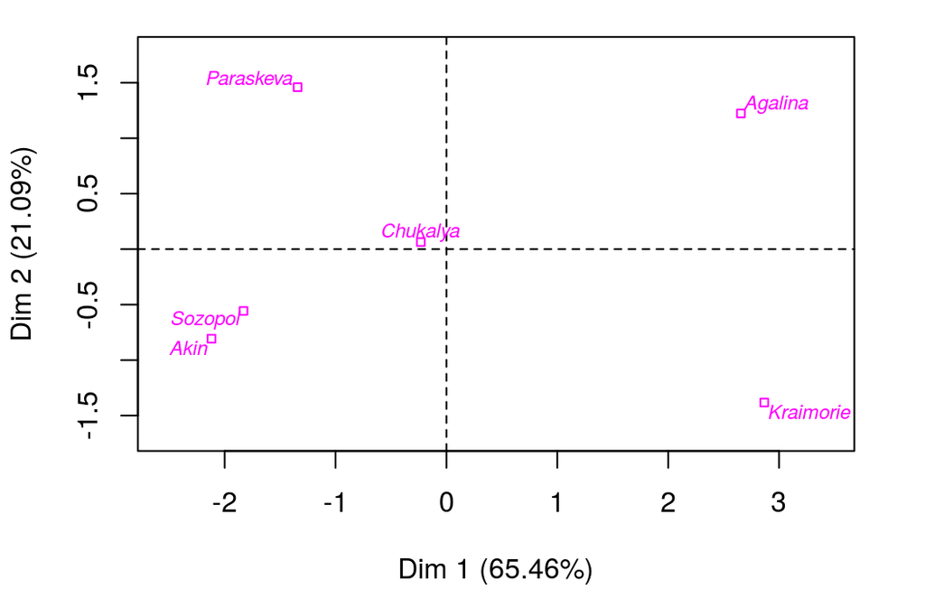

**Figure 3.4 - Qualitative factor map (PCA)** *The labeled factors are those the best shown on the plane.*

The **dimension 1** opposes individuals such as *2*, *1*, *14*, *13*, *15* and *3* (to the right of the graph, characterized by a strongly positive coordinate on the axis) to individuals such as *7*, *9* and *8* (to the left of the graph, characterized by a strongly negative coordinate on the axis).

The group in which the individuals *2*, *14*, *13* and *15* stand (characterized by a positive coordinate on the axis) is sharing :

- high values for the variables *gravel*, *moisture_content*, *mean_grain_size* and *sorting* (variables are sorted from the strongest).
- low values for the variable *sand*.

The group in which the individuals *1* and *3* stand (characterized by a positive coordinate on the axis) is sharing :

- high values for the variables *silt_clay*, *TOM* and *sorting* (variables are sorted from the strongest).

The group in which the individuals *7*, *9* and *8* stand (characterized by a negative coordinate on the axis) is sharing :

- high values for the variable *sand*.
- low values for the variables *mean_grain_size*, *sorting*, *gravel*, *TOM* and *moisture_content* (variables are sorted from the weakest).

### 4. Classification

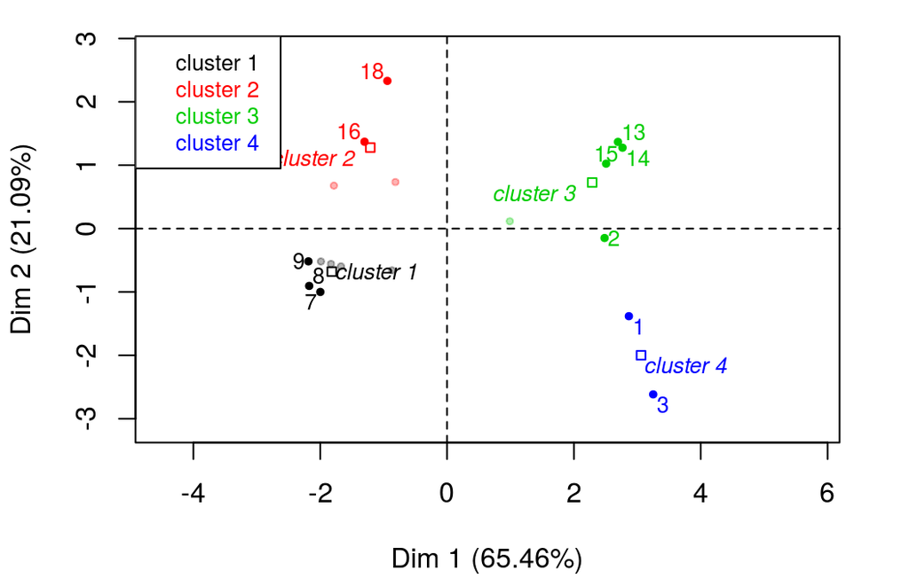

**Figure 4 - Ascending Hierarchical Classification of the individuals.** *The classification made on individuals reveals 4 clusters.*

The **cluster 1** is made of individuals such as *7*, *8* and *9*. This group is characterized by :

- high values for the variable *sand*.
- low values for the variables *TOM*, *moisture_content*, *sorting*, *mean_grain_size* and *gravel* (variables are sorted from the weakest).

The **cluster 2** is made of individuals such as *16* and *18*. This group is characterized by :

- high values for the variable *moisture_content*.

The **cluster 3** is made of individuals such as *2*, *13*, *14* and *15*. This group is characterized by :

- high values for the variables *gravel*, *mean_grain_size* and *sorting* (variables are sorted from the strongest).
- low values for the variable *sand*.

The **cluster 4** is made of individuals such as *1* and *3*. This group is characterized by :

- high values for the variables *silt_clay*, *TOM* and *sorting* (variables are sorted from the strongest).

## Annexes

```r
dimdesc(res, axes = 1:1)
```

```
$Dim.1
$Dim.1$quanti
                correlation      p.value
sorting           0.9791880 1.658076e-12
mean_grain_size   0.9647738 1.067384e-10
gravel            0.9392585 7.693319e-09
TOM               0.7724857 1.717173e-04
sand             -0.9658770 8.303956e-11

$Dim.1$quali
               R2      p.value
station 0.9615384 4.513937e-08

$Dim.1$category
          Estimate     p.value
Kraimorie 2.866538 0.006464586
Agalina   2.656248 0.013320233
```

**Figure 5 - List of variables characterizing the dimensions of the analysis.**

```r
res.hcpc$desc.var
```

```
Link between the cluster variable and the categorical variables (chi-square test)
=================================================================================
             p.value df
station 0.0007645037 15

Description of each cluster by the categories
=============================================
$`1`
                Cla/Mod  Mod/Cla   Global    p.value   v.test
station=Sozopol     100 42.85714 16.66667 0.04289216 2.024759
station=Akin        100 42.85714 16.66667 0.04289216 2.024759

$`2`
                  Cla/Mod Mod/Cla   Global     p.value   v.test
station=Paraskeva     100      75 16.66667 0.004901961 2.813407

$`3`
                Cla/Mod Mod/Cla   Global   p.value   v.test
station=Agalina     100      60 16.66667 0.0122549 2.504718

$`4`
                   Cla/Mod Mod/Cla   Global    p.value   v.test
station=Kraimorie 66.66667     100 16.66667 0.01960784 2.333769


Link between the cluster variable and the quantitative variables
================================================================
                      Eta2      P-value
mean_grain_size  0.9966771 1.403397e-17
sorting          0.9779834 7.802836e-12
sand             0.8876251 6.751758e-07
gravel           0.8778000 1.208228e-06
silt_clay        0.8429471 6.877304e-06
TOM              0.7935668 4.543328e-05
moisture_content 0.7505368 1.670030e-04

Description of each cluster by quantitative variables
=====================================================
$`1`
                    v.test Mean in category  Overall mean sd in category
```

[output cut: 26 more lines]

```
                Overall sd      p.value
gravel           0.9718253 0.0007286296
mean_grain_size  0.9718253 0.0009701622
sorting          0.9718253 0.0056540858
sand             0.9718253 0.0017923846

$`4`
            v.test Mean in category  Overall mean sd in category
silt_clay 3.605766         2.403844  5.204170e-18      0.6805247
TOM       2.804268         1.869512 -1.881211e-16      0.3433571
sorting   2.314212         1.542808 -9.560254e-17      0.1579682
          Overall sd      p.value
silt_clay  0.9718253 0.0003112334
TOM        0.9718253 0.0050431044
sorting    0.9718253 0.0206560778
```

**Figure 6 - List of variables characterizing the clusters of the classification.**